# Lab 6: Text Mining

Author

Nate Truettner

## Setup

```r
library(dplyr)
library(ggplot2)
library(tidytext)
library(stringr)
library(tidyr)
library(conflicted)
conflict_prefer("count", "dplyr")
```

```
[conflicted] Will prefer dplyr::count over any other package.
```

```r
conflict_prefer("filter", "dplyr")
```

```
[conflicted] Will prefer dplyr::filter over any other package.
```

```r
conflict_prefer("select", "dplyr")
```

```
[conflicted] Will prefer dplyr::select over any other package.
```

```r
url <- "https://raw.githubusercontent.com/dmcable/BIOSTAT620W26/main/data/mtsamples/mtsamples.csv"
medical <- read.csv(url)
```

## 1

```r
medical %>%
  dplyr::count(medical_specialty, sort = TRUE)
```

```
                medical_specialty    n
1                         Surgery 1103
2      Consult - History and Phy.  516
3      Cardiovascular / Pulmonary  372
4                      Orthopedic  355
5                       Radiology  273
6                General Medicine  259
7                Gastroenterology  230
8                       Neurology  223
9   SOAP / Chart / Progress Notes  166
10        Obstetrics / Gynecology  160
11                        Urology  158
12              Discharge Summary  108
13           ENT - Otolaryngology   98
14                   Neurosurgery   94
```

[output cut: 26 more lines]

We have 40 different specialties listed in this dataset. Surgery is far and away the most common specialty with over 1100 observations, while there are many specialties that have fewer than 100 observations; this is not an even distribution. “General medicine” is very broad and likely includes multiple specialties. Other than that, I do not notice a ton of overlap among the specialties.

## 2

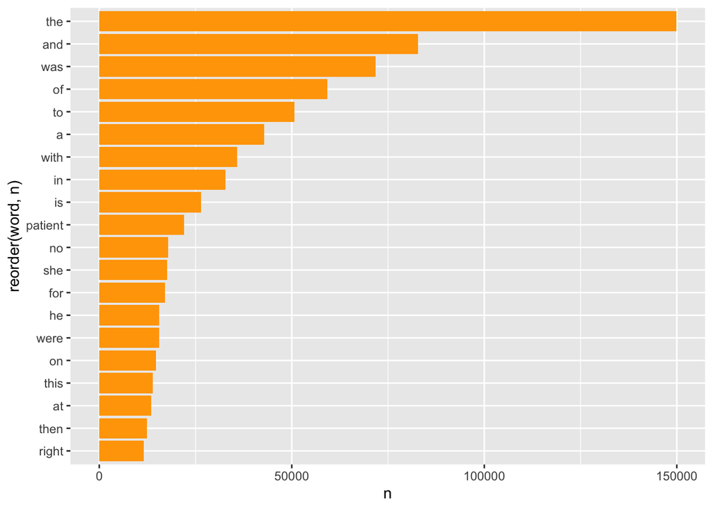

```r
medical_words <- medical |>
  unnest_tokens(word, transcription) |>
  count(word, sort = TRUE)
top20 <- medical_words[1:20,]
ggplot(top20, aes(x = reorder(word, n), y = n)) +
  geom_col(fill='orange') +
  coord_flip()
```

This result makes sense as the transcription column consists of full sentences that include many stop words; therefore we would expect to see “the”, “and”, and “to” quite a bit among others. “Patient” is the most common non-stop word, which makes sense as the transcriptions often discuss the patient. Beyond this, we won’t be able to learn a whole lot from this plot.

## 3

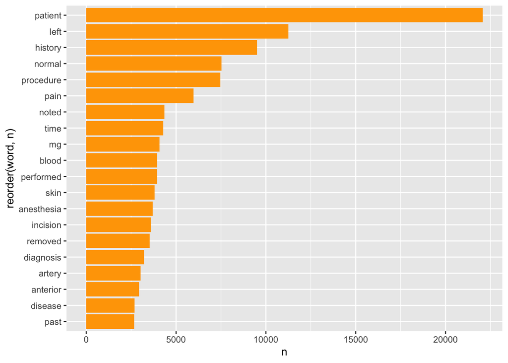

```r
medical_words <- medical |>
  unnest_tokens(word, transcription) |>
  anti_join(stop_words, by = "word") |>
  filter(!str_detect(word, "^[0-9]+$")) |>
  count(word, sort = TRUE)
top20 <- medical_words[1:20,]
ggplot(top20, aes(x = reorder(word, n), y = n)) +
  geom_col(fill='orange') +
  coord_flip()
```

Now that we have removed the stop words, it becomes more clear what the transcriptions actually commonly consist of. Words like “procedure”, “pain”, “blood”, and “anesthesia” now appear in the top 20, which are much more descriptive and reflect what caregivers are seeing in their hospitals.

## 4

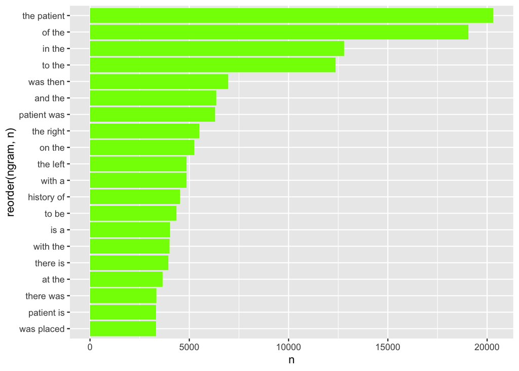

```r
medical_grams <- medical |>
  unnest_ngrams(ngram, transcription, n = 2) |>
  count(ngram, sort = TRUE)
top20_gram <- medical_grams[1:20,]
ggplot(top20_gram, aes(x = reorder(ngram, n), y = n)) +
  geom_col(fill='chartreuse') +
  coord_flip()
```

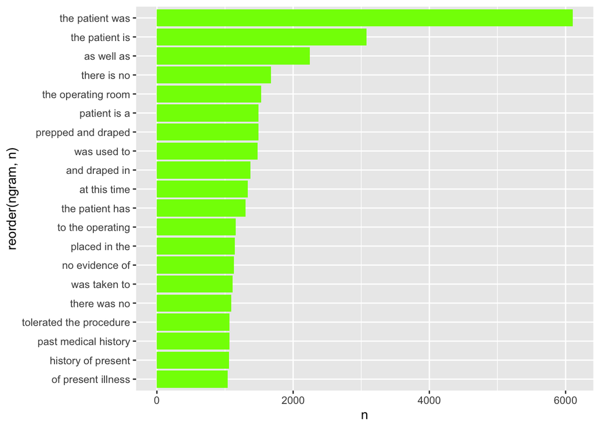

```r
medical_grams <- medical |>
  unnest_ngrams(ngram, transcription, n = 3) |>
  count(ngram, sort = TRUE)
top20_gram <- medical_grams[1:20,]
ggplot(top20_gram, aes(x = reorder(ngram, n), y = n)) +
  geom_col(fill='chartreuse') +
  coord_flip()
```

Looking at the most common bi-grams, we notice that many of these common bi-grams are just combinations of stop words, like “of the” and “in the”. Some interesting ones include “history of” and “was placed”, but without removing stop words it’s not very informative. The tri-gram plot is a bit more interesting, as snippets like “the operating room”, “prepped and draped”, and “tolerated the procedure” are much more informative.

## 5

```r
medical |>
  unnest_ngrams(ngram, transcription, n = 2) |>
  separate(ngram, into = c("word1", "word2"), sep = " ") |>
  dplyr::select(word1, word2) |>
  dplyr::filter(word1 == "patient") |>
  dplyr::count(word2, sort = TRUE) |>
  head(20)
```

```
        word2    n
1         was 6293
2          is 3332
3         has 1417
4   tolerated  994
5         had  888
6        will  616
7      denies  552
8         and  377
9      states  363
10       does  334
11       also  301
12         in  246
13        did  232
14         to  215
15        the  200
16  underwent  180
17   received  160
18    reports  155
19       with  141
20 understood  113
```

```r
medical |>
  unnest_ngrams(ngram, transcription, n = 2) |>
  separate(ngram, into = c("word1", "word2"), sep = " ") |>
  dplyr::select(word1, word2) |>
  dplyr::filter(word2 == "patient") |>
  dplyr::count(word1, sort = TRUE) |>
  head(20)
```

```
         word1     n
1          the 20307
2         this   470
3      history   101
4            a    67
5          and    47
6    procedure    32
7       female    26
8         with    25
9          use    24
10         old    23
11      sample    23
12        male    22
13         new    19
14     general    16
15     illness    16
16        plan    16
17 indications    15
18          to    15
19        your    15
20   allergies    14
```

I chose “patient” as my word to be analyzed; common words that follow patient are “tolerated”, “denies”, and “states”. Common words that precede patient include “history”, “procedure”, and “female”. I’m guessing that history and procedure were the end of the previous sentence in these cases as it wouldn’t make sense to have them immediately precede patient within a sentence.

## 6

```r
medical |>
  unnest_tokens(word, transcription) |>
  anti_join(stop_words, by = "word") |>
  dplyr::filter(!is.na(medical_specialty)) |>
  dplyr::group_by(medical_specialty, word) |>
  dplyr::summarise(n = n(), .groups = "drop") |>
  dplyr::group_by(medical_specialty) |>
  top_n(5, n) |>
  arrange(medical_specialty, desc(n))
```

```
# A tibble: 209 × 3
# Groups:   medical_specialty [40]
   medical_specialty       word          n
   <chr>                   <chr>     <int>
 1 " Allergy / Immunology" history      38
 2 " Allergy / Immunology" noted        23
 3 " Allergy / Immunology" patient      22
 4 " Allergy / Immunology" allergies    21
 5 " Allergy / Immunology" nasal        13
 6 " Allergy / Immunology" past         13
 7 " Autopsy"              left         83
 8 " Autopsy"              1            66
 9 " Autopsy"              inch         59
10 " Autopsy"              neck         55
# ℹ 199 more rows
```

Picking out some results from this large table: the dentistry specialty has many mentions of “tooth” and “teeth”, ENT includes “nasal” and “ear”, and pain management includes “needle” and “injected”. These all make sense in the context of the types of cases each specialty would treat.

## 7

I would like to revisit question 4 and find common tri-grams with stop words removed.

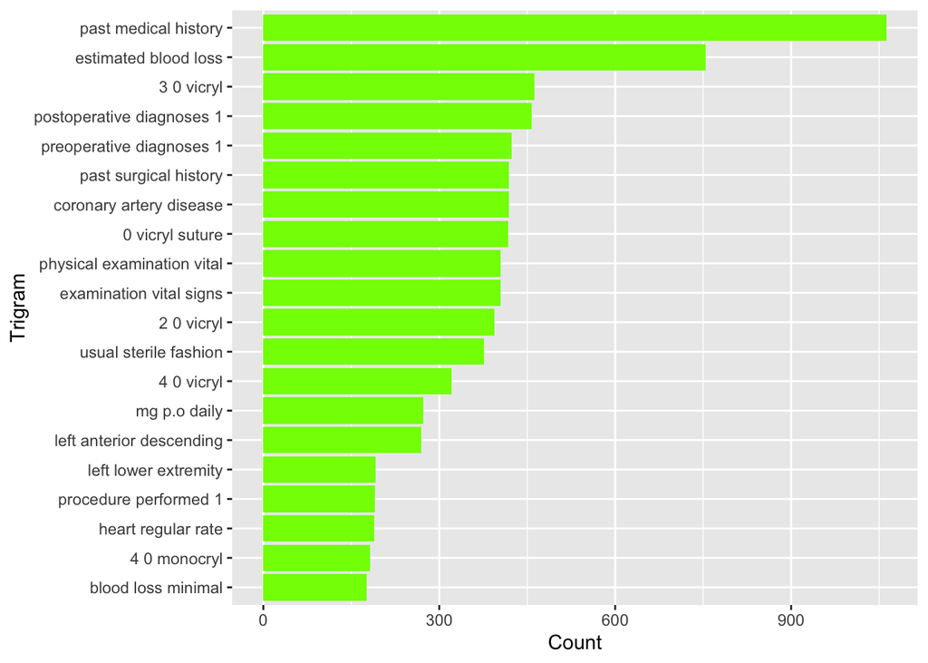

```r
medical_grams <- medical |>
  unnest_ngrams(ngram, transcription, n = 3) |>
  separate(ngram, into = c("word1", "word2", "word3"), sep = " ") |>
  anti_join(stop_words, by = c("word1" = "word")) |>
  anti_join(stop_words, by = c("word2" = "word")) |>
  anti_join(stop_words, by = c("word3" = "word")) |>
  unite(ngram, word1, word2, word3, sep = " ") |>
  dplyr::count(ngram, sort = TRUE)

top20_gram <- medical_grams[1:20, ]

ggplot(top20_gram, aes(x = reorder(ngram, n), y = n)) +
  geom_col(fill = "chartreuse") +
  coord_flip() +
  labs(x = "Trigram", y = "Count")
```

Analyzing these results, we unsurpisingly see “past medical history” as the most common tri-gram. We also have common trigrams of “estimated blood loss”, “usual sterile fashion”, and “heart regular rate”. These are common phrases in the medical field that I’m not shocked to see in this plot.